# NYPD Crime Complaint Analysis

Alison Polito

2023-12-15

```r
library(tidyverse)
library(lubridate)
library(leaflet)
```

## Overview

In 2016, the city of New York created a [dataset of crime complaints](https://data.cityofnewyork.us/Public-Safety/NYPD-Complaint-Data-Current-Year-To-Date-/5uac-w243) that documents criminal incidents reported to the New York City Police Department — resulting in a report of all valid felony, misdemeanor, and violation crimes. Updated as of November 8th, 2023, the data features 415,310 rows, each representing a criminal complaint filed within the city. Specific details about the type of crime, location, time of enforcement, and demographic information of victims and suspects are captured with 36 different variables. The data provides a comprehensive look into the frequency and types of crime that occur in the city. This data is released based on the date the incident was reported, not necessarily when it occurred. Therefore, it is possible that some crimes occurred years before they were reported to the NYPD.

New York is ranked the [largest city in the country](https://worldpopulationreview.com/us-cities), with over 8.5 million residents. While New York is safer compared to many large U.S. cities, such as St. Louis, Missouri and Detroit, Michigan, understanding the crime outlook has benefits for the improvement of general public safety and the promotion of economic development. This NYC Crime Complaint analysis specifically focuses on the years 2017-2023, aiming to uncover the nature of crime in the city by exploring spatial, temporal, and socio-demographic trends present in the data. For those who live in the city or plan to visit, this information is useful for community awareness. When exposing patterns in crime, it is possible to enforce policies and strategies to prevent future crime. Lastly, honest data analysis helps to provide accurate and timely information which can combat common misconceptions about crimes rates and demographic information. With the presence of media, political, and social influence, some may believe that crime is much more common than it actually is. This data helps enforce the fact that New York City is actually one of the safest cities in the country, while helping to paint an unbiased and holistic picture of crime over the past six years.

## Variable Explanations

- `CMPLNT_NUM` Randomly generated persistent ID for each complaint.
- `ADDR_PCT_CD`The precinct in which the incident occurred.
- `BORO_NM` The name of the borough in which the incident occurred.
- `CMPLNT_FR_DT` Exact date of occurrence for the reported event.
- `CMPLNT_FR_TM` Exact time of occurrence for the reported event.
- `CMPLNT_TO_DT` Ending date of occurrence for the reported event, if exact time of occurrence is unknown.
- `CMPLNT_TO_TM`Ending time of occurrence for the reported event, if exact time of occurrence is unknown.
- `CRM_ATPT_CPTD_CD` Indicator of whether crime was successfully completed or attempted, but failed or was interrupted prematurely.
- `JURISDICTION_CODE` Jurisdiction responsible for incident. Either internal, like Police(0), Transit(1), and Housing(2); or external(3), like Correction, Port Authority, etc.
- `JURIS_DESC` Description of the jurisdiction code
- `KY_CD` Three digit offense classification code
- `LAW_CAT_CD` Level of offense: felony, misdemeanor, violation
- `LOC_OF_OCCUR_DESC` Specific location of occurrence in or around the premises; inside, opposite of, front of, rear of
- `OFNS_DESC` Description of offense corresponding with key code
- `PARKS_NM` Name of NYC park, playground or greenspace of occurrence, if applicable (state parks are not included)
- `PATROL_BORO` The name of the patrol borough in which the incident occurred.
- `PD_CD` Three digit internal classification code (more granular than Key Code)
- `PD_DESC` Description of internal classification corresponding with PD code (more granular than Offense Description)
- `premise_desc` Specific description of premises; grocery store, residence, street, etc.
- `SUSP_AGE_GROUP` Suspect’s Age Group
- `SUSP_RACE` Suspect’s Race Description
- `SUSP_SEX` Suspect’s Sex Description
- `VIC_AGE_GROUP` Victim’s Age Group
- `VIC_RACE` Victim’s Race Description
- `VIC_SEX` Victim’s Sex Description
- `X_COORD_CD`X-coordinate for New York State Plane Coordinate System, Long Island Zone, NAD 83, units feet (FIPS 3104)
- `Y_COORD_CD` Y-coordinate for New York State Plane Coordinate System, Long Island Zone, NAD 83, units feet (FIPS 3104)
- `Latitude` Midblock Latitude coordinate for Global Coordinate System, WGS 1984, decimal degrees (EPSG 4326)
- `Longitude` Midblock Longitude coordinate for Global Coordinate System, WGS 1984, decimal degrees (EPSG 4326)
- `Lat_Lon` Latitude & Longitude

Upon inspecting my data, there are quite a few NA values. To make things easier, I am going to read in some of the problematic columns as character values and then use the `lubridate` package to specify their structures later.

```r
crime <- read_csv("NYPD_Complaint_Data2_Current__Year_To_Date__20231210.csv",
                   col_types = cols(
    CMPLNT_NUM = col_character(),
    ADDR_PCT_CD = col_double(),
    BORO_NM = col_character(),
    CMPLNT_FR_DT = col_character(),
    CMPLNT_TO_DT = col_character()
    ))
```

## Data Preparation

First, I am de-selecting rows that won’t be useful for the analysis due to excessive NA values. I am also renaming some column names and offense descriptions for clarity.

```r
crime <- crime %>%
  select(-HADEVELOPT, -HOUSING_PSA, -PARKS_NM, -RPT_DT, -STATION_NAME, -TRANSIT_DISTRICT) %>%
  rename(
    complaint_num = CMPLNT_NUM,
    precinct_num = ADDR_PCT_CD,
    date_start = CMPLNT_FR_DT,
    date_end = CMPLNT_TO_DT,
    offense_level = LAW_CAT_CD,
    offense_desc = OFNS_DESC,
    premise_desc = PREM_TYP_DESC
    ) %>%
  mutate(offense_desc = ifelse(offense_desc == 'OFF. AGNST PUB ORD SENSBLTY &', 'OFFENSE AGAINST PUBLIC ORDER/ADMIN', offense_desc),
         offense_desc = ifelse(offense_desc == 'CRIMINAL MISCHIEF & RELATED OF', 'VANDALISM & RELATED', offense_desc),
         offense_desc = ifelse(offense_desc == 'HARRASSMENT 2', 'HARASSMENT', offense_desc))
```

I am using the `mdy()` function from the `lubridate` package to translate the date_start values into the proper date format.

```r
# Date Formatting
crime$date_start <- mdy(crime$date_start)
 # Ensuring it is the correct data type and is formatted correct as dates
str(crime$date_start)
```

```
##  Date[1:415310], format: "2021-12-04" "2023-07-01" "2023-06-09" "2023-07-02" "2023-09-19" ...
```

The date_end column is going to require further cleaning. It has NA values throughout so I will flag these values by creating a new column, and then using a placeholder value so that I do not have to delete the entire row, since there are other important pieces of information.

```r
# First flagging the missing values by creating a new column
crime$date_end_missing <- is.na(crime$date_end)

# Adding placeholder value -- I chose '12/10/1999'
placeholder <- "12/10/1999"
crime$date_end[is.na(crime$date_end)] <- placeholder

# Finally converting the column to the proper date format
crime$date_end <- mdy(crime$date_end)
str(crime$date_end)
```

```
##  Date[1:415310], format: "1999-12-10" "1999-12-10" "1999-12-10" "2023-07-02" "2023-09-19" ...
```

I’ve encountered a new problem — there are year typos such as 1022 and 1023 in the `date_start` column. I suspect they are supposed to be 2022 and 2023, but to simplify the data and preserve data integrity, I have decided to use 2017 as the earliest date.

```r
# Specifying dates to include
crime <- crime %>%
filter(date_start >= as.Date("2017-01-01"),
         date_end >= as.Date("2017-01-01") | date_end == as.Date("1999-12-10"))
```

There are a few more NA values I want to take care of in the suspect and victim demographic columns. I am going to fill them in with “UNKNOWN.”

```r
crime <- crime %>%
  mutate(SUSP_AGE_GROUP = ifelse(SUSP_AGE_GROUP == "(null)", "UNKNOWN", SUSP_AGE_GROUP),
         SUSP_RACE = ifelse(SUSP_RACE == "(null)", "UNKNOWN", SUSP_RACE),
         SUSP_SEX = ifelse(SUSP_SEX == "(null)", "UNKNOWN", SUSP_SEX),
         VIC_AGE_GROUP = ifelse(VIC_AGE_GROUP == "(null)", "UNKNOWN", VIC_AGE_GROUP),
         VIC_SEX = ifelse(VIC_SEX == "(null)", "UNKNOWN", VIC_SEX),
         VIC_RACE = ifelse(VIC_RACE == "(null)", "UNKNOWN", VIC_RACE))
str(crime$SUSP_AGE_GROUP)
```

```
##  chr [1:414677] "25-44" "25-44" "25-44" "45-64" "UNKNOWN" "25-44" "25-44" ...
```

## Analysis

First, I’m curious to compare the percentage of crimes attempted to crimes completed. What percentage of crime complaints were attempted?

```r
crime_compare <- crime %>%
  group_by(CRM_ATPT_CPTD_CD) %>%
  summarize(count = n())
crime_compare
```

```
## # A tibble: 2 × 2
##   CRM_ATPT_CPTD_CD  count
##   <chr>             <int>
## 1 ATTEMPTED          5972
## 2 COMPLETED        408705
```

**Attempted crimes only make up about 1.44% of the total crime complaints.**

What are the most common types of crime in New York City?

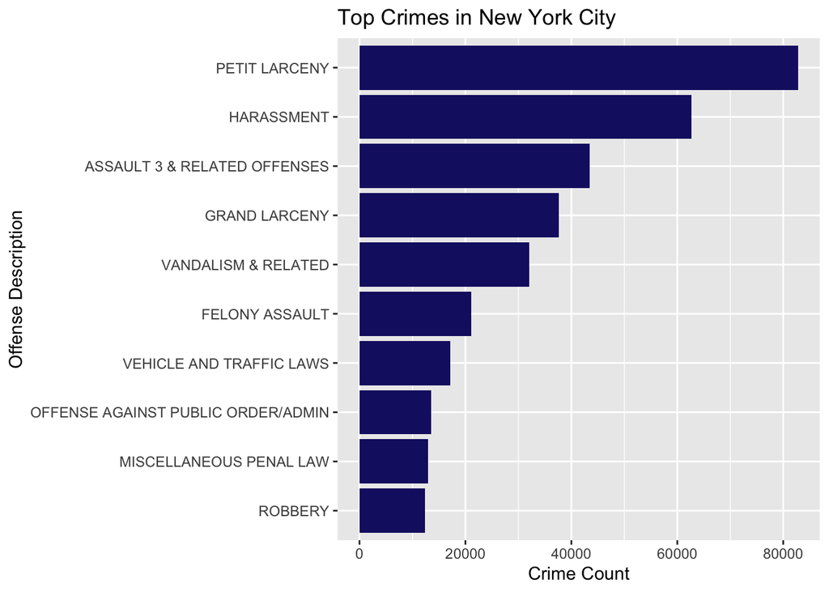

```r
crime_type <- crime %>%
  group_by(offense_desc) %>%
  summarize(crime_count = n()) %>%
  arrange(desc(crime_count)) %>%
  slice_max(order_by=crime_count, n=10)


crime_type <- crime_type[order(-crime_type$crime_count), ]


crime_plot <- ggplot(crime_type, aes(x=crime_count, y=reorder(offense_desc, crime_count))) +
  geom_bar(stat ="identity", fill="#191970") +
  labs(title="Top Crimes in New York City",
       x="Crime Count",
       y="Offense Description") +
  theme(axis.text.y=element_text(hjust=1))
crime_plot
```

What was the most common crime in each year from 2017-2023?

```r
crime_year <- crime %>%
  mutate(year = year(date_start)) %>%
  group_by(year, offense_desc) %>%
  summarize(totalcrime= n()) %>%
  slice_max(totalcrime, n=1)
crime_year
```

```
## # A tibble: 7 × 3
## # Groups:   year [7]
##    year offense_desc  totalcrime
##   <dbl> <chr>              <int>
## 1  2017 SEX CRIMES            40
## 2  2018 SEX CRIMES            48
## 3  2019 SEX CRIMES            49
## 4  2020 GRAND LARCENY         72
## 5  2021 GRAND LARCENY        168
## 6  2022 PETIT LARCENY       2096
## 7  2023 PETIT LARCENY      80524
```

**In 2023, petit larceny was the most common crime with 80524 cases. However, I have found an important limitation in this data — there are many more complaints stored for 2023 compared to the past years.**

How many complaints are stored for each year?

```r
count_2017 <- crime %>%
  filter(substr(date_start,1,4)=="2017") %>%
  nrow()
count_2018<- crime %>%
  filter(substr(date_start,1,4)=="2018") %>%
  nrow()
count_2019<- crime %>%
  filter(substr(date_start,1,4)=="2019") %>%
  nrow()
count_2020<- crime %>%
  filter(substr(date_start,1,4)=="2020") %>%
  nrow()
count_2021<- crime %>%
  filter(substr(date_start,1,4)=="2021") %>%
  nrow()
count_2022<- crime %>%
  filter(substr(date_start,1,4)=="2022") %>%
  nrow()
count_2023<- crime %>%
  filter(substr(date_start,1,4)=="2023") %>%
  nrow()

cat(count_2017, "complaints were stored in 2017.\n")
```

```
## 83 complaints were stored in 2017.
```

```r
cat(count_2018, "complaints were stored in 2018.\n")
```

```
## 137 complaints were stored in 2018.
```

```r
cat(count_2019, "complaints were stored in 2019.\n")
```

```
## 208 complaints were stored in 2019.
```

```r
cat(count_2020, "complaints were stored in 2020.\n")
```

```
## 332 complaints were stored in 2020.
```

```r
cat(count_2021, "complaints were stored in 2021.\n")
```

```
## 804 complaints were stored in 2021.
```

```r
cat(count_2022, "complaints were stored in 2022.\n")
```

```
## 8544 complaints were stored in 2022.
```

```r
cat(count_2023, "complaints were stored in 2023.\n")
```

```
## 404569 complaints were stored in 2023.
```

How common is each type of offense?

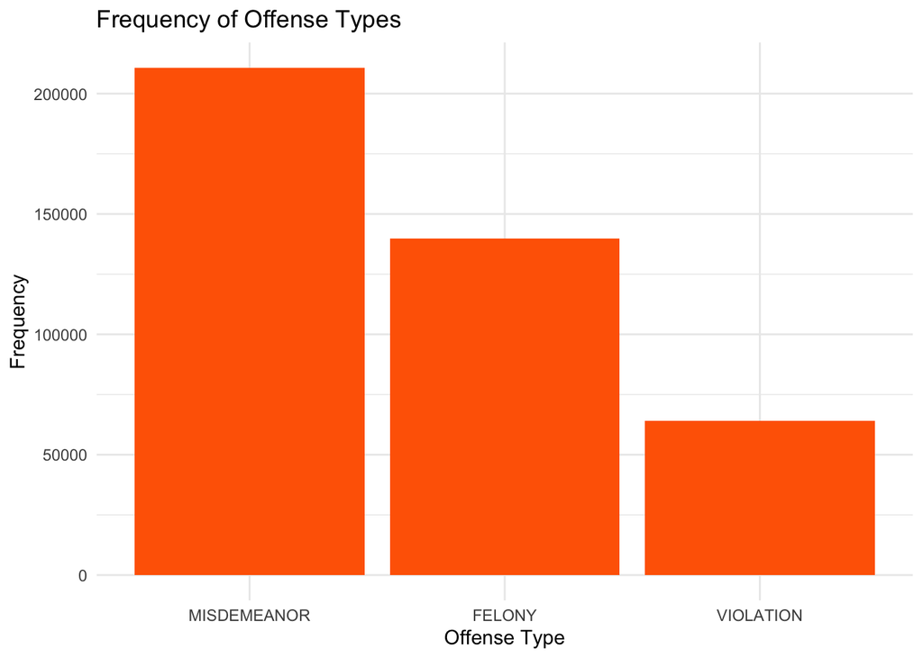

```r
offense_freq <- crime %>%
  count(offense_level) %>%
  arrange(desc(n))

ggplot(offense_freq, aes(x=reorder(offense_level,-n), y=n)) +
  geom_bar(stat="identity", fill="#FF6600") +
  labs(title="Frequency of Offense Types",
       x="Offense Type",
       y="Frequency") +
  theme_minimal()
```

**Misdemeanors are the most common type of offense.** In New York, a violation is defined as any non-criminal offense, other than traffic infractions. The maximum punishment includes 15 days in jail and a $250 fine. Example: disorderly conduct.

## Investigating Victim Demographics

Since 2017, which age group has been most commonly targeted as victims of crime?

```r
vic_age <- crime %>%
  mutate(VIC_AGE_GROUP = ifelse(VIC_AGE_GROUP == "UNKNOWN", NA, VIC_AGE_GROUP)) %>%
  group_by(VIC_AGE_GROUP) %>%
  filter(!is.na(VIC_AGE_GROUP) & !(VIC_AGE_GROUP < 0 | VIC_AGE_GROUP > 66)) %>%
  count() %>%
  filter(n>5)
vic_age
```

```
## # A tibble: 4 × 2
## # Groups:   VIC_AGE_GROUP [4]
##   VIC_AGE_GROUP      n
##   <chr>          <int>
## 1 18-24          33988
## 2 25-44         146810
## 3 45-64          77247
## 4 65+            21465
```

Which sex made up the largest proportion of victims?

```r
vic_sex <- crime %>%
  mutate(VIC_SEX = ifelse(VIC_SEX == "UNKNOWN", NA, VIC_SEX)) %>%
  group_by(VIC_SEX) %>%
  count() %>%
# In the VIC_SEX column, there are the following values: D, E, F, M, L, U (D=Business/Organization, E=PSNY/People of the State of New York, F=Female, M=Male). There is no documentation for L (n=3176) or U (n=1). I've decided to just select Male and Female for my analysis.
filter(VIC_SEX == "M" | VIC_SEX == "F")
vic_sex
```

```
## # A tibble: 2 × 2
## # Groups:   VIC_SEX [2]
##   VIC_SEX      n
##   <chr>    <int>
## 1 F       157452
## 2 M       143380
```

Which races made up the largest proportion of victims?

```r
vic_race <- crime %>%
  group_by(VIC_RACE) %>%
  count()
vic_race
```

```
## # A tibble: 7 × 2
## # Groups:   VIC_RACE [7]
##   VIC_RACE                            n
##   <chr>                           <int>
## 1 AMERICAN INDIAN/ALASKAN NATIVE   1806
## 2 ASIAN / PACIFIC ISLANDER        32540
## 3 BLACK                          100214
## 4 BLACK HISPANIC                  18340
## 5 UNKNOWN                        128931
## 6 WHITE                           58251
## 7 WHITE HISPANIC                  74595
```

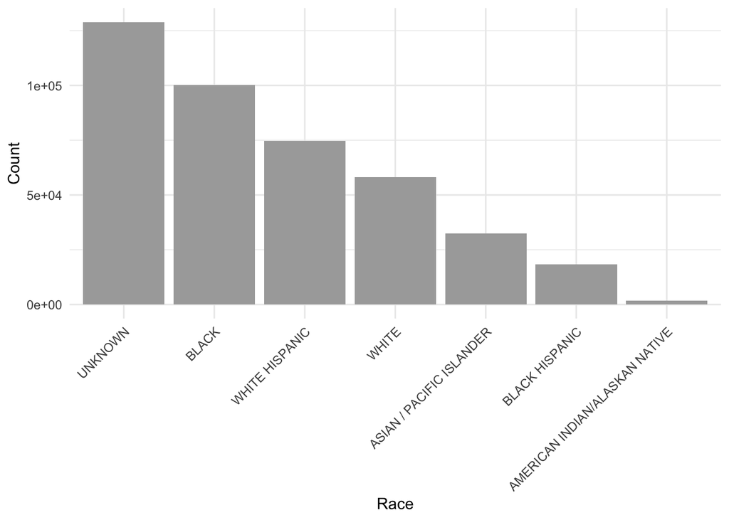

```r
vic_race_plot <- ggplot(vic_race, aes(x = reorder(VIC_RACE, -n), y=n)) +
  geom_bar(stat="identity", fill="#A9A9A9") +
  labs(y="Count") +
  labs(x="Race") +
  theme_minimal() +
  theme(axis.text.x = element_text(angle = 45, hjust = 1))
vic_race_plot
```

The data contains a high count of ‘UNKNOWN’ victim race values. Excluding this result, **the most common victims of crime were individuals of Black and White Hispanic races, females, and those in the 25-44 age group.** Females and males made up a similar proportion of crime victims — there is approximately a 9.36% difference between the two groups.

## Investigating Suspect Demographics

Which age group made up the largest proportion of suspects since 2017?

```r
susp_age <- crime %>%
  mutate(SUSP_AGE_GROUP = ifelse(SUSP_AGE_GROUP == "UNKNOWN", NA, SUSP_AGE_GROUP)) %>%
  group_by(SUSP_AGE_GROUP) %>%
  filter(!is.na(SUSP_AGE_GROUP) & !(SUSP_AGE_GROUP > 66 | SUSP_AGE_GROUP < 0)) %>%
 group_by(SUSP_AGE_GROUP) %>%
 count() %>%
filter(SUSP_AGE_GROUP %in% c("18-24", "25-44", "45-64", "65+"))
susp_age
```

```
## # A tibble: 4 × 2
## # Groups:   SUSP_AGE_GROUP [4]
##   SUSP_AGE_GROUP      n
##   <chr>           <int>
## 1 18-24           30462
## 2 25-44          116162
## 3 45-64           40095
## 4 65+              4442
```

Which sex made up the largest proportion of suspects?

```r
susp_sex <- crime %>%
  mutate(SUSP_SEX = ifelse(SUSP_SEX == "UNKNOWN", NA, SUSP_SEX)) %>%
  group_by(SUSP_SEX) %>%
  count() %>%
  filter(SUSP_SEX == "M" | SUSP_SEX == "F")
susp_sex
```

```
## # A tibble: 2 × 2
## # Groups:   SUSP_SEX [2]
##   SUSP_SEX      n
##   <chr>     <int>
## 1 F         57587
## 2 M        209241
```

Which races made up the largest proportion of suspects?

```r
susp_race <- crime %>%
  group_by(SUSP_RACE) %>%
  count()
susp_race
```

```
## # A tibble: 7 × 2
## # Groups:   SUSP_RACE [7]
##   SUSP_RACE                           n
##   <chr>                           <int>
## 1 AMERICAN INDIAN/ALASKAN NATIVE    859
## 2 ASIAN / PACIFIC ISLANDER        13018
## 3 BLACK                          125846
## 4 BLACK HISPANIC                  20028
## 5 UNKNOWN                        165195
## 6 WHITE                           29953
## 7 WHITE HISPANIC                  59778
```

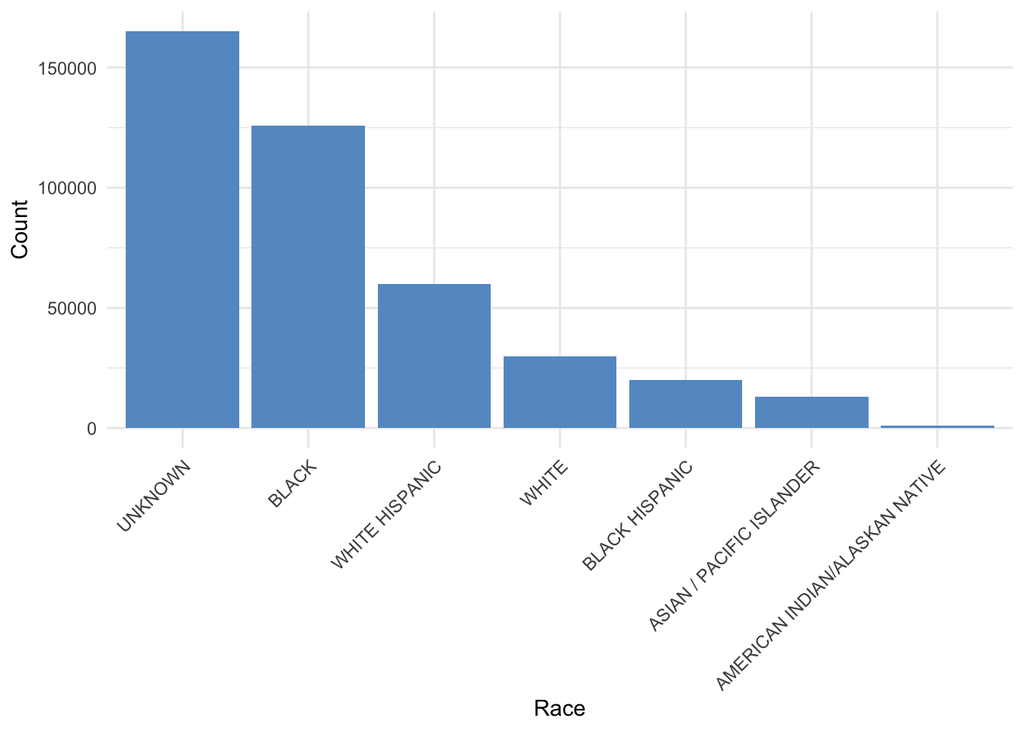

```r
susp_race_plot <- ggplot(susp_race, aes(x = reorder(SUSP_RACE, -n), y=n)) +
  geom_bar(stat="identity", fill="#6699CC") +
  labs(y="Count") +
  labs(x="Race") +
  theme_minimal() +
  theme(axis.text.x = element_text(angle = 45, hjust = 1))
susp_race_plot
```

Where did most crime occur?

```r
crime_location <- crime %>%
  filter(!is.na(Latitude) & !is.na(Longitude)) %>%
  group_by(Latitude, Longitude) %>%
  summarize(crime_count = n()) %>%
  arrange(desc(crime_count))
top_10 <- head(crime_location, 10)
top_10
```

```
## # A tibble: 10 × 3
## # Groups:   Latitude [10]
##    Latitude Longitude crime_count
##       <dbl>     <dbl>       <int>
##  1     40.8     -74.0        1320
##  2     40.8     -73.9         833
##  3     40.7     -73.8         693
##  4     40.7     -73.9         677
##  5     40.7     -73.9         670
##  6     40.7     -74.0         659
##  7     40.8     -73.8         634
##  8     40.8     -73.9         586
##  9     40.7     -74.0         530
## 10     40.9     -73.9         518
```

Where did the most crime occur in the city?

```r
color <- colorNumeric(
  palette="viridis",
  domain=top_10$crime_count
)
crime_map <- leaflet() %>%
  addProviderTiles(leaflet::providers$CartoDB.Positron) %>%
  addCircleMarkers(
    data=top_10,
    lat=~Latitude,
    lng=~Longitude,
    popup=~paste("Crime Count: ", crime_count),
    color=color(top_10$crime_count),
    fillOpacity = 0.7,
    radius=10
  ) %>%
  addLegend(
    "bottomright",
    pal=color,
    values=top_10$crime_count,
    title="Crime Count",
    opacity=1
  )
crime_map
```

[interactive chart not shown]

**The point with the highest crime count (1,320) is located on the border of the Garment District, just south of Times Square. Outside of Manhattan, Brooklyn and Queens had lower crime counts ranging from 530-693.**

## Main Findings

From making this comparison over the years, I found an important limitation with this dataset. There are many more complaints stored for 2023 compared to past years, especially from 2017-2020. However, as the data documentation explains, the complaint is based on the report date, rather than occurrence date. The original data ranged from the 1990s to 2023, but there were many inconsistencies in the older data, and limited entries. Additionally, there were incorrect year entries which further complicated matters. Therefore, for the purpose of this analysis, I decided to have a more contemporary focus by only including data since 2017.

These results represent a preliminary analysis of the NYPD Crime Complaint dataset. For further study, additional data cleaning steps and joining with other datasets would be helpful. While this data contains insightful trends and covers a lot of ground, the data was inherently flawed and required a lot of preparation. Some of the columns mostly consisting of NA values proved to be insignificant for this analysis. While this data has temporal limitations, it effectively reveals key information about the nature of crime in New York City, including detailed information on the suspects and victims, and precise geospatial information.

## References

[New York State Law Penal Law](https://ypdcrime.com/penal.law/violations.php#:~:text=%22Violation%22%20means%20an%20offense%2C,fifteen%20days%20cannot%20be%20imposed.)